# Hepatitis A Report

Fereidoun Mianji

10/29/2020

1. Introduction:

The effectiveness of public vaccnation on the infection rate of Hepatitis A is studied in the Us by state. This shows the trend of the disease over about half a century. The analysis is based on the weekly statistics collected across the states. As the dataset includes many disease, first we need to filter it to only keep Hepatitis data for the years that a minimum of 30 weeks are repoted for it.

```r
library(tidyverse)
library(dslabs)

data(us_contagious_diseases)
the_case <- "Hepatitis A"

HepatitisA_dat <- us_contagious_diseases %>%
  filter(weeks_reporting >= 30) %>%
  filter(disease == the_case) %>%
  mutate(disease_rate = count / population * 10^4 * 52 / weeks_reporting) %>%  ## calc. rate per ten tousands
  mutate(state = reorder(state, disease_rate))
save(HepatitisA_dat, file = 'rdas/HepatitisA_dat.rda')
```

2. Comparing geographical zones:

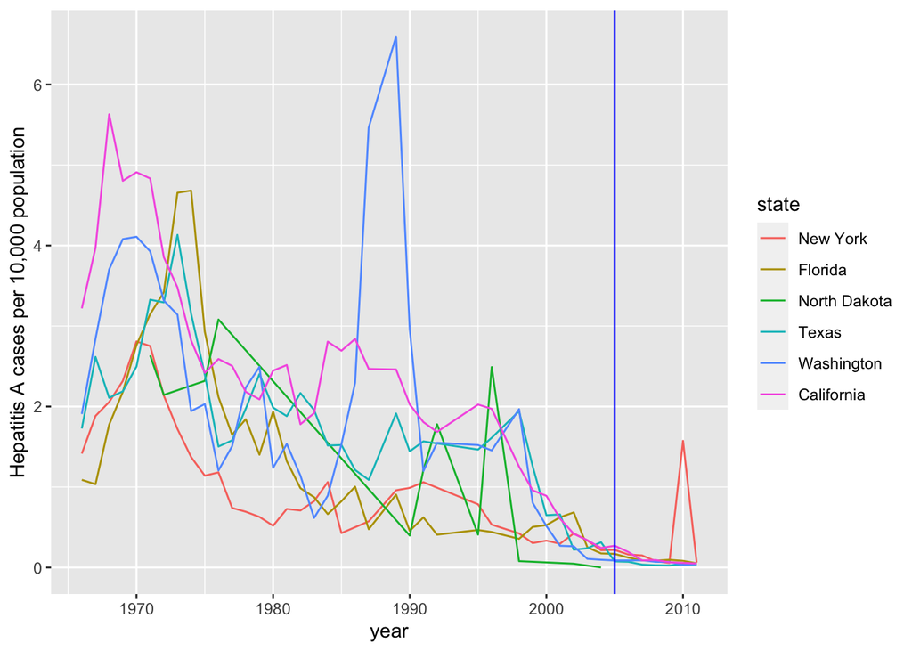

```r
library(RColorBrewer)


load("rdas/HepatitisA_dat.rda")
the_case <- "Hepatitis A"
HepatitisA_dat %>% filter(state %in% c("Texas", "Florida", "California", "New York",
                      "Washington", "North Dakota") &!is.na(disease_rate)) %>%
  ggplot(aes(year, disease_rate, col = state)) +
  geom_line() +
  ylab("Hepatitis A cases per 10,000 population") +
  geom_vline(xintercept=2005, col = "blue") +
  ggsave('fig/sample-states-trend.png')
```

3. Comparing all the states in a single plot:

Its very informative to compare all the states on a single graph to see if they all have followed the same trend.

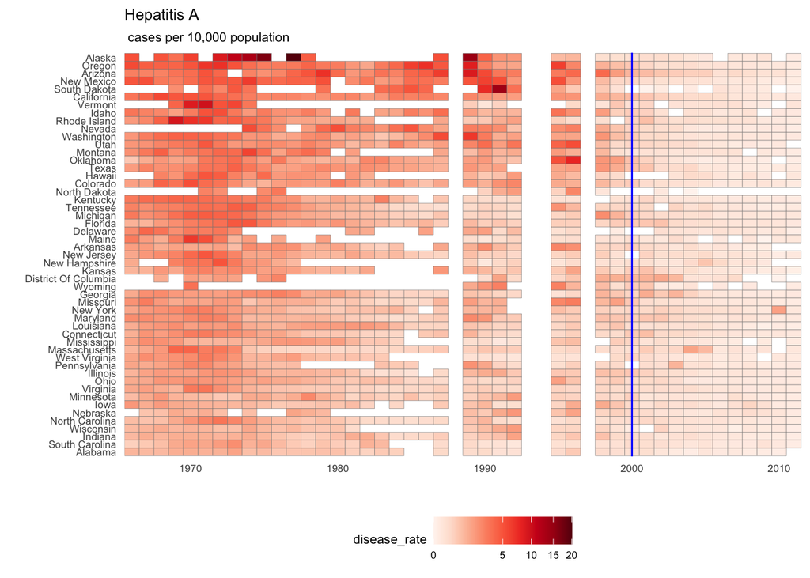

```r
HepatitisA_dat %>% ggplot(aes(year, state, fill = disease_rate)) +
  geom_tile(color = "grey50") +
  scale_x_continuous(expand=c(0,0)) +
  scale_fill_gradientn(colors = brewer.pal(9, "Reds"), trans = "sqrt") +
  geom_vline(xintercept=2000, col = "blue") +
  theme_minimal() +
  theme(panel.grid = element_blank(),
        legend.position="bottom",
        text = element_text(size = 8)) +
  ggtitle(the_case, ' cases per 10,000 population') +
  ylab("") + xlab("") +
  ggsave("fig/all-states-trend.png")
```

4. The US average:

```r
avg <- us_contagious_diseases %>%
  filter(disease==the_case) %>% group_by(year) %>%
  summarize(us_rate = sum(count, na.rm = TRUE) /
              sum(population, na.rm = TRUE) * 10000)
```

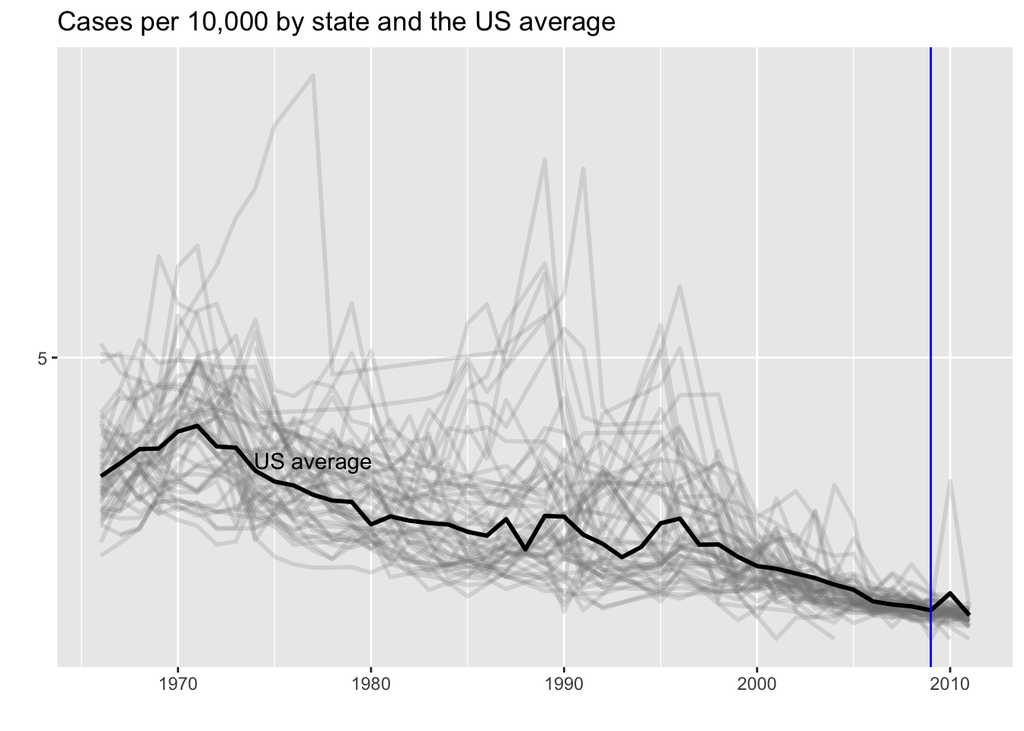

```r
HepatitisA_dat %>%
  filter(!is.na(disease_rate)) %>%
  ggplot() +
  geom_line(aes(year, disease_rate, group = state), color = "grey50",
            show.legend = FALSE, alpha = 0.2, size = 1) +
  geom_line(mapping = aes(year, us_rate), data = avg, size = 1) +
  scale_y_continuous(trans = "sqrt", breaks = c(5, 25, 125, 300)) +
  ggtitle("Cases per 10,000 by state and the US average") +
  xlab("") + ylab("") +
  geom_text(data = data.frame(x = 1977, y = 2),
            mapping = aes(x, y, label="US average"),
            color="black") +
  geom_vline(xintercept=2009, col = "blue") +
  ggsave("fig/us-average.png")
```